# Projekt modele liniowe i mieszane

Zadanie I

Aleksandra Dąbrowska, Jan Dmitruk, Magda Młynarczyk

20 March 2017

# Problem

W pierwszej fazie projektu chcemy znaleźć model liniowy opisujący zależność długości rozwiązywania zadań z matematyki i parametrów zadań. Dla wybranego modelu przeprowadzimy diagnostykę i wizualizację.

# Obróbka danych

Pierwszym krokiem w naszej analizie była transformacja danych `actionTimeScoreMath`.

```r
library(dplyr)
library(MASS)
library(knitr)
library(lmtest)
library(car)
library(stringr)
library(broom)
library(ggplot2)
```

Czas podpunktu został zamieniony na sekundy,dodaliśmy kolumny z numerem zadania i podpunktu, wartości `NA` w kolumnie S zmieniliśmy na wartość `No answer`. Z kolumny position usunęliśmy wartości `-1`. Z kolumny `BOOKID` usunęliśmy elementy z wartością `rm`. Obcieliśmy także1 procent najwiekszych i najmniejszych czasów.

W nowych danych mamy następujące kolumny:

- `id_kraju` kod kraju
- `id_szkoły` kod szkoły
- `id_ucznia` kod ucznia
- `id_kwestionariusza` kod kwestionariusza
- `kod_zadania` pełny kod zadania (`item_short` w pierwotnych danych)
- `typ_zadania` czy zadanie było matematyczne
- `liczba_akcji` liczba akcji którą wykonał uczeń
- `wynik` z jakim skutkiem zostało rozwiązane zadanie
- `pozycja_zadania` w której części całego kwestionariusza znajdowało się zadanie
- `czas` czas rozwiązywania pojedynczego podpunktu
- `zadanie` numer zadania
- `podpunkt` numer podpunktu
- `czas_zadania` czas rozwiązywania całego zadania
- `suma_akcji` ile akcji uczeń potrzebował na całe zadanie
- `liczba_podpunktow` ile podpunktów miało zadanie
- `wynik_podpunktu` jeśli podpunkt rozwiązany to 1 w przeciwnym przypadku 0
- `wynik_zadania` suma wyników podpunktów z poszczególnych zadań

```r
#setwd(dirname(rstudioapi::getActiveDocumentContext()$path))

load("dane_matematyka2.rda")

x <-c("id_kraju","id_szkoły","id_ucznia","id_kwestionariusza","kod_zadania","typ_zadania","liczba_akcji","wynik","pozycja_zadania","czas","zadanie","podpunkt","czas_zadania","suma_akcji","liczba_podpunktow","wynik_podpunktu","wynik_zadania")

colnames(dane_pelne) <- x
dane_pelne <- droplevels(dane_pelne)
dane_pelne$id_kraju<- str_replace_all(dane_pelne$id_kraju, fixed(" "), "")
```

## Wybór danych

W naszych danych mamy informacje z 73 krajów. Jednak do tworzenia analiz wybraliśmy 5.

```r
kraje <- c("DEU","FIN","POL","TUR","USA")

dane_pelne$id_kraju <- as.character(dane_pelne$id_kraju)

wybranekraje <- dane_pelne$id_kraju %in% kraje

data <- dane_pelne[wybranekraje,]

data$podpunkt <- as.factor(data$podpunkt)
dane <- data

rm(dane_pelne,wybranekraje, kraje,x,data)


head(dane,4)
```

```
##         id_kraju id_szkoly id_ucznia id_kwestionariusza kod_zadania
## 1187033      FIN  24600031  24600001                 53     M033Q01
## 1187034      FIN  24600031  24600001                 53     M474Q01
## 1187035      FIN  24600031  24600001                 53     M155Q01
## 1187036      FIN  24600031  24600001                 53     M155Q04
##         typ_zadania liczba_akcji       wynik pozycja_zadania    czas
## 1187033          CM            3 Full credit               2  36.722
## 1187034          CM            2 Full credit               2  42.144
## 1187035          CM           42 Full credit               2 127.376
## 1187036          CM            6 Full credit               2  81.902
##         zadanie podpunkt czas_zadania suma_akcji liczba_podpunktow
## 1187033     033        1       36.722          3                 1
## 1187034     474        1       42.144          2                 1
## 1187035     155        1      463.898        121                 4
## 1187036     155        4      463.898        121                 4
##         wynik_podpunktu wynik_zadania
## 1187033            1.00           1.0
## 1187034            1.00           1.0
## 1187035            0.25           0.5
## 1187036            0.25           0.5
```

# Modele

## Model czas podpunktu

W pierwszych modelach chcemy objaśniać zmienną `czas`. W naszych danych jest to liczba mówiąca jak długo uczeń rozwiązuje konkretny podpunkt zadania.

```r
model_podpunkt_1 <- lm(czas~kod_zadania,data=dane)

model_podpunkt_2 <- lm(czas~kod_zadania+id_kwestionariusza+pozycja_zadania, data = dane)

model_podpunkt_3 <- lm(czas~zadanie/podpunkt+id_kwestionariusza+pozycja_zadania, data = dane)
```

```r
anova(model_podpunkt_1)
```

```
## Analysis of Variance Table
##
## Response: czas
##                 Df    Sum Sq Mean Sq F value    Pr(>F)
## kod_zadania     69 186300514 2700007  778.59 < 2.2e-16 ***
## Residuals   251360 871670143    3468
## ---
## Signif. codes:  0 '***' 0.001 '**' 0.01 '*' 0.05 '.' 0.1 ' ' 1
```

```r
anova(model_podpunkt_2)
```

```
## Analysis of Variance Table
##
## Response: czas
##                        Df    Sum Sq Mean Sq F value    Pr(>F)
## kod_zadania            69 186300514 2700007 790.980 < 2.2e-16 ***
## id_kwestionariusza     35  10820271  309151  90.567 < 2.2e-16 ***
## pozycja_zadania         2   2960133 1480067 433.593 < 2.2e-16 ***
## Residuals          251323 857889738    3413
## ---
## Signif. codes:  0 '***' 0.001 '**' 0.01 '*' 0.05 '.' 0.1 ' ' 1
```

```r
anova(model_podpunkt_3)
```

```
## Analysis of Variance Table
##
## Response: czas
##                        Df    Sum Sq Mean Sq F value    Pr(>F)
## zadanie                39  95797471 2456345 719.598 < 2.2e-16 ***
## id_kwestionariusza     35  10729911  306569  89.811 < 2.2e-16 ***
## pozycja_zadania         2   2955991 1477996 432.986 < 2.2e-16 ***
## zadanie:podpunkt       30  90597545 3019918 884.700 < 2.2e-16 ***
## Residuals          251323 857889738    3413
## ---
## Signif. codes:  0 '***' 0.001 '**' 0.01 '*' 0.05 '.' 0.1 ' ' 1
```

We wszytskich powyższych modelach wybrane zmienne okazują się istotne.

## Model czas zadania

Następną zmienną objaśnianą jest czas całego zadania, czyli zsumowane czasy podpunktów.

```r
dane_model <- dane[,c(4,9,11,13,15)]
dane_model <- unique(dane_model)
dane_model$zadanie <- factor(dane_model$zadanie)

model_zadanie_1 <- lm(czas_zadania~id_kwestionariusza+zadanie, data=dane_model)

model_zadanie_2 <- lm(czas_zadania~zadanie+id_kwestionariusza+pozycja_zadania, data = dane_model)

model_zadanie_3 <- lm(czas_zadania~zadanie*pozycja_zadania+id_kwestionariusza, data = dane_model)
```

```r
anova(model_zadanie_1)
```

```
## Analysis of Variance Table
##
## Response: czas_zadania
##                        Df     Sum Sq  Mean Sq F value    Pr(>F)
## id_kwestionariusza     35  169447974  4841371  607.78 < 2.2e-16 ***
## zadanie                39  870888215 22330467 2803.36 < 2.2e-16 ***
## Residuals          145149 1156201341     7966
## ---
## Signif. codes:  0 '***' 0.001 '**' 0.01 '*' 0.05 '.' 0.1 ' ' 1
```

```r
anova(model_zadanie_2)
```

```
## Analysis of Variance Table
##
## Response: czas_zadania
##                        Df     Sum Sq  Mean Sq  F value    Pr(>F)
## zadanie                39 1021915982 26202974 3300.776 < 2.2e-16 ***
## id_kwestionariusza     35   18420206   526292   66.297 < 2.2e-16 ***
## pozycja_zadania         2    3962335  1981167  249.567 < 2.2e-16 ***
## Residuals          145147 1152239006     7938
## ---
## Signif. codes:  0 '***' 0.001 '**' 0.01 '*' 0.05 '.' 0.1 ' ' 1
```

```r
anova(model_zadanie_3)
```

```
## Analysis of Variance Table
##
## Response: czas_zadania
##                             Df     Sum Sq  Mean Sq   F value    Pr(>F)
## zadanie                     39 1021915982 26202974 3321.1070 < 2.2e-16 ***
## pozycja_zadania              3   17318108  5772703  731.6636 < 2.2e-16 ***
## id_kwestionariusza          34    5064433   148954   18.8792 < 2.2e-16 ***
## zadanie:pozycja_zadania    107    7897890    73812    9.3553 < 2.2e-16 ***
## Residuals               145040 1144341116     7890
## ---
## Signif. codes:  0 '***' 0.001 '**' 0.01 '*' 0.05 '.' 0.1 ' ' 1
```

## Podsumowanie modeli

Ze wszytskich modeli “wyciągniemy” informacje na temat statystyk

```r
glance_pod_1 <-glance(model_podpunkt_1)
glance_pod_2 <-glance(model_podpunkt_2)
glance_pod_3 <-glance(model_podpunkt_3)
glance_zad_1 <-glance(model_zadanie_1)
glance_zad_2 <-glance(model_zadanie_2)
glance_zad_3 <-glance(model_zadanie_3)

glance_tab <- rbind(glance_pod_1,glance_pod_2,glance_pod_3,glance_zad_1,glance_zad_2,glance_zad_3)

kable(glance_tab)
```

| r.squared | adj.r.squared | sigma | statistic | p.value | df | logLik | AIC | BIC | deviance | df.residual |
| --- | --- | --- | --- | --- | --- | --- | --- | --- | --- | --- |
| 0.1760923 | 0.1758662 | 58.88816 | 778.5902 | 0 | 70 | -1381466.9 | 2763076 | 2763817 | 871670143 | 251360 |
| 0.1891176 | 0.1887756 | 58.42512 | 552.9687 | 0 | 107 | -1379463.6 | 2759143 | 2760270 | 857889738 | 251323 |
| 0.1891176 | 0.1887756 | 58.42512 | 552.9687 | 0 | 107 | -1379463.6 | 2759143 | 2760270 | 857889738 | 251323 |
| 0.4736255 | 0.4733571 | 89.25031 | 1764.9100 | 0 | 75 | -858292.0 | 1716736 | 1717487 | 1156201341 | 145149 |
| 0.4754294 | 0.4751547 | 89.09786 | 1730.9183 | 0 | 77 | -858042.7 | 1716241 | 1717013 | 1152239006 | 145147 |
| 0.4790250 | 0.4783677 | 88.82472 | 728.7491 | 0 | 184 | -857543.3 | 1715457 | 1717286 | 1144341116 | 145040 |

Patrząc na współczynnik AIC dla wszytskich modeli dla objaśniania czasu wybralibyśmy `model_podpunkt_3`, a dla czasu całego zadania `model_zadanie_3`.

Zastosujemy jeszcze transformacje zmiennej objaśnianej.

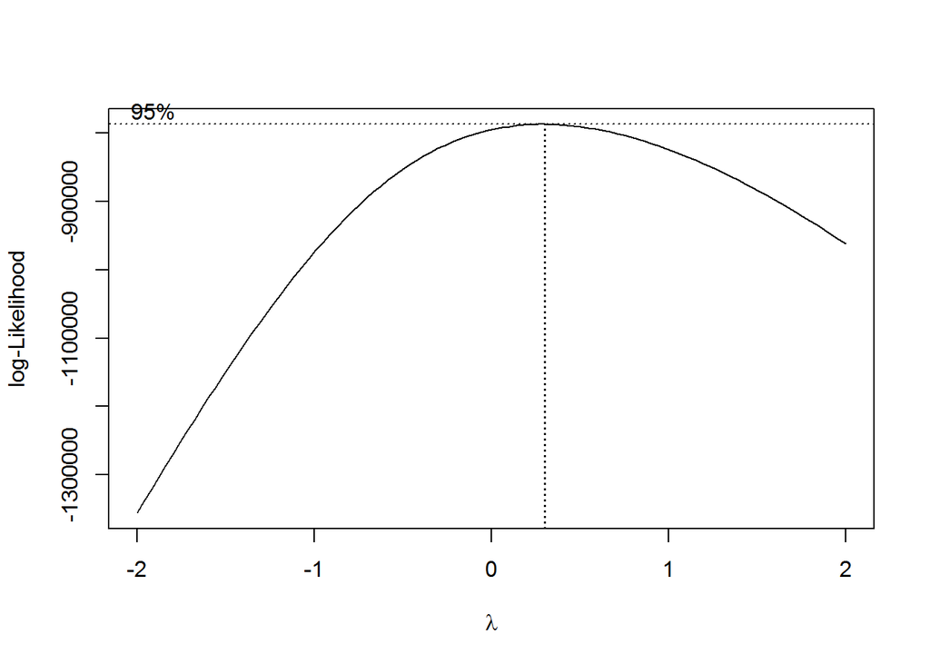

```r
wsp <- boxcox(model_zadanie_3)
```

```r
wsp <- wsp$x[which.max(wsp$y)]

model_zadanie_3_box <- lm((czas_zadania)^wsp~zadanie*pozycja_zadania+id_kwestionariusza, data = dane_model)
glance(model_zadanie_3_box)
```

```
##   r.squared adj.r.squared     sigma statistic p.value  df    logLik
## 1  0.478557     0.4778991 0.7580218  727.3837       0 184 -165738.6
##        AIC      BIC deviance df.residual
## 1 331847.1 333676.1 83339.57      145040
```

```r
model_zadanie_3_log <- lm(log(czas_zadania)~zadanie*pozycja_zadania+id_kwestionariusza, data = dane_model)
glance(model_zadanie_3_log)
```

```
##   r.squared adj.r.squared     sigma statistic p.value  df    logLik
## 1 0.4382408      0.437532 0.6247006  618.3001       0 184 -137646.5
##        AIC      BIC deviance df.residual
## 1 275662.9 277491.9 56601.98      145040
```

```r
model_zadanie_3 <- model_zadanie_3_log
```